# Course Project: Prediction Assignment Writeup

Author: Serge

November 13, 2015

### Executive Summary

Using devices such as Jawbone Up, Nike FuelBand, and Fitbit it is now possible to collect a large amount of data about personal activity relatively inexpensively. These type of devices are part of the quantified self movement - a group of enthusiasts who take measurements about themselves regularly to improve their health, to find patterns in their behavior, or because they are tech geeks. One thing that people regularly do is quantify how much of a particular activity they do, but they rarely quantify how well they do it. 6 participants were asked to perform barbell lifts correctly and incorrectly in 5 different ways. In this project, data from accelerometers on the belt, forearm, arm, and dumbell of 6 participants has been used to predict the manner in which they did the exercise. Selected Random Forest model shows 0.9788 accuracy for cross validation data set and all 20 test submissions were correct.

### Data Loading, Processing and Exploratory analysis

The data for this project come from http://groupware.les.inf.puc-rio.br/har.

```r
library(caret)
wd="~/work/Prediction-Assignment-Writeup"
setwd(wd)

# loading  data

if(! file.exists("pml-testing.csv")){
    fileURL="https://d396qusza40orc.cloudfront.net/predmachlearn/pml-training.csv"
    download.file(fileURL, destfile="pml-training.csv", method="curl", quiet="True")
    fileURL="https://d396qusza40orc.cloudfront.net/predmachlearn/pml-testing.csv"
    download.file(fileURL, destfile="pml-testing.csv", method="curl", quiet="True")
}

pml.training = read.csv("pml-training.csv")
pml.testing = read.csv("pml-testing.csv")
```

Detailed data summary can be found in the Appendix. Training data set consists of 160 columns and 19622 observations. Testing data set consists of 160 columns and 20 observations.

Based on an assumption, that variables “X”, timestamps, “num_window” and “num_window” do not bring any added value to predict the manner of the exercise, these variables will be removed from both data sets.

```r
pml.training = pml.training[,- c(1,3:7)]
pml.testing = pml.testing[,- c(1,3:7)]
```

Next step is to identify uninformative features, including “not available”, in testing data set and remove from both data sets. “User_name” variable to be converted from factor to numeric to keep data consistency. Finally, we’ll split training set into sub-training/test sets for further validation.

```r
# select informative features from pml.testing set and remove from both data sets
pml.testing.cols = NULL
for (f in 1:(dim(pml.testing)[2]-1)) {
  if(length(unique(pml.testing[[f]]))>1){
    pml.testing.cols = c(pml.testing.cols,f)
  }
}

pml.training = data.frame(pml.training[pml.testing.cols], classe=pml.training$classe)
pml.testing = pml.testing[pml.testing.cols]

# convert "user_name" from factor to numeric
pml.training$user_name=as.numeric(pml.training$user_name)
pml.testing$user_name=as.numeric(pml.testing$user_name)

# create train/test data sets
set.seed(10)
inTrain <- createDataPartition(y=pml.training$classe,p=0.75, list=FALSE)
training <- pml.training[inTrain,]
testing <- pml.training[-inTrain,]
```

We still have relatively big amount of regressors - 53.To reduce data dimension, we’ll preprocess data set with PCA method (99% cutoff for the cumulative percent of variance to be retained). PCA will help reduce number of predictors, and noise, avoid overfitting on training data and minimize out of sample error rate.

```r
# create PCA preprocess object
PC.preProc <- preProcess(training[,-ncol(training)], method="pca", thresh = 0.99)
training.PC <- predict(PC.preProc, training[,-ncol(training)])
testing.PC <- predict(PC.preProc, testing[,-ncol(testing)])

training.PC=data.frame(training.PC, classe=training$classe)
```

This gives us 36 PCA features instead of 53.

Diagram 1 (see Appendix below) shows PCA plot of the first two (main) components colored by “classe” variable (outcome). We can identify at least 4 clusters (most likely 5 or 6, taking in to account size of the largest cluster).

In the next diagram (Diagram 2), we colored PCA plot by “user-name”. 6 cluster (users) are clearly identified on this plot.

It would be interesting to predict each “user_name” based on measured data, but this question is out of the project’s scope.

### Model Selection, Training and Prediction

Taking in to account that Random Forest is one of the most powerful ensemble learning method for classification, let’s use “rf” method, train our model on preprocessed training data set, predict outcome for sub-test(validation) set and print a confusion matrix.

```r
# train the data using random forest model
rf.fit <- train(classe ~ .,method="rf",data=training.PC)
rf.fit
```

```
## Random Forest
##
## 14718 samples
##    36 predictor
##     5 classes: 'A', 'B', 'C', 'D', 'E'
##
## No pre-processing
## Resampling: Bootstrapped (25 reps)
##
## Summary of sample sizes: 14718, 14718, 14718, 14718, 14718, 14718, ...
##
## Resampling results across tuning parameters:
##
##   mtry  Accuracy   Kappa      Accuracy SD  Kappa SD
##    2    0.9705821  0.9627669  0.002725976  0.003458319
##   19    0.9642814  0.9547942  0.003463226  0.004390380
##   36    0.9485471  0.9348801  0.005792101  0.007359501
##
## Accuracy was used to select the optimal model using  the largest value.
## The final value used for the model was mtry = 2.
```

```r
# predict outcome for test/validation data set using the random forest model and print the confusion matrix
testing.pred <- predict(rf.fit,testing.PC)
confusionMatrix(testing$classe,testing.pred)
```

```
## Confusion Matrix and Statistics
##
##           Reference
## Prediction    A    B    C    D    E
##          A 1390    3    2    0    0
##          B   15  928    6    0    0
##          C    2   14  837    2    0
##          D    0    0   44  758    2
##          E    0    1    9    3  888
##
## Overall Statistics
##
##                Accuracy : 0.979
##                  95% CI : (0.9746, 0.9828)
##     No Information Rate : 0.2869
##     P-Value [Acc > NIR] : < 2.2e-16
##
##                   Kappa : 0.9734
##  Mcnemar's Test P-Value : NA
##
## Statistics by Class:
##
##                      Class: A Class: B Class: C Class: D Class: E
## Sensitivity            0.9879   0.9810   0.9321   0.9934   0.9978
## Specificity            0.9986   0.9947   0.9955   0.9889   0.9968
## Pos Pred Value         0.9964   0.9779   0.9789   0.9428   0.9856
## Neg Pred Value         0.9952   0.9954   0.9849   0.9988   0.9995
## Prevalence             0.2869   0.1929   0.1831   0.1556   0.1815
## Detection Rate         0.2834   0.1892   0.1707   0.1546   0.1811
## Detection Prevalence   0.2845   0.1935   0.1743   0.1639   0.1837
## Balanced Accuracy      0.9932   0.9878   0.9638   0.9912   0.9973
```

Random Forest model shows 0.9789967 accuracy and 0.0210033 out of sample error.

### Submission Validation and Conclusion

Finally, let’s apply the machine learning algorithm we built to each of the 20 test cases in the testing data set.

```r
#predict submission outcome for test data set using the random forest model
pml.testing.pred <- predict(rf.fit, predict(PC.preProc, pml.testing))
pml.testing.pred
```

```
##  [1] B A B A A E D B A A B C B A E E A B B B
## Levels: A B C D E
```

```r
answers = as.character(pml.testing.pred)
pml_write_files = function(x){
  n = length(x)
  for(i in 1:n){
    filename = paste0("problem_id_",i,".txt")
    write.table(x[i],file=filename,quote=FALSE,row.names=FALSE,col.names=FALSE)
  }
}
pml_write_files(answers)
```

All 20 test cases have been submitted and correct. Therefore, our assumption about 0.0210033 out of sample error rate is most likely valid.

### Appendix

#### Data set summary

```r
dim(pml.training)
```

```
## [1] 19622    54
```

```r
dim(pml.testing)
```

```
## [1] 20 53
```

```r
head(pml.training)
```

```
##   user_name roll_belt pitch_belt yaw_belt total_accel_belt gyros_belt_x
## 1         2      1.41       8.07    -94.4                3         0.00
## 2         2      1.41       8.07    -94.4                3         0.02
## 3         2      1.42       8.07    -94.4                3         0.00
## 4         2      1.48       8.05    -94.4                3         0.02
## 5         2      1.48       8.07    -94.4                3         0.02
## 6         2      1.45       8.06    -94.4                3         0.02
##   gyros_belt_y gyros_belt_z accel_belt_x accel_belt_y accel_belt_z
## 1         0.00        -0.02          -21            4           22
## 2         0.00        -0.02          -22            4           22
## 3         0.00        -0.02          -20            5           23
## 4         0.00        -0.03          -22            3           21
## 5         0.02        -0.02          -21            2           24
## 6         0.00        -0.02          -21            4           21
##   magnet_belt_x magnet_belt_y magnet_belt_z roll_arm pitch_arm yaw_arm
```

[output cut: 69 more lines]

```r
head(pml.testing)
```

```
##   user_name roll_belt pitch_belt yaw_belt total_accel_belt gyros_belt_x
## 1         6    123.00      27.00    -4.75               20        -0.50
## 2         5      1.02       4.87   -88.90                4        -0.06
## 3         5      0.87       1.82   -88.50                5         0.05
## 4         1    125.00     -41.60   162.00               17         0.11
## 5         4      1.35       3.33   -88.60                3         0.03
## 6         5     -5.92       1.59   -87.70                4         0.10
##   gyros_belt_y gyros_belt_z accel_belt_x accel_belt_y accel_belt_z
## 1        -0.02        -0.46          -38           69         -179
## 2        -0.02        -0.07          -13           11           39
## 3         0.02         0.03            1           -1           49
## 4         0.11        -0.16           46           45         -156
## 5         0.02         0.00           -8            4           27
## 6         0.05        -0.13          -11          -16           38
##   magnet_belt_x magnet_belt_y magnet_belt_z roll_arm pitch_arm yaw_arm
```

[output cut: 69 more lines]

```r
names(pml.training)
```

```
##  [1] "user_name"            "roll_belt"            "pitch_belt"
##  [4] "yaw_belt"             "total_accel_belt"     "gyros_belt_x"
##  [7] "gyros_belt_y"         "gyros_belt_z"         "accel_belt_x"
## [10] "accel_belt_y"         "accel_belt_z"         "magnet_belt_x"
## [13] "magnet_belt_y"        "magnet_belt_z"        "roll_arm"
## [16] "pitch_arm"            "yaw_arm"              "total_accel_arm"
## [19] "gyros_arm_x"          "gyros_arm_y"          "gyros_arm_z"
## [22] "accel_arm_x"          "accel_arm_y"          "accel_arm_z"
## [25] "magnet_arm_x"         "magnet_arm_y"         "magnet_arm_z"
## [28] "roll_dumbbell"        "pitch_dumbbell"       "yaw_dumbbell"
## [31] "total_accel_dumbbell" "gyros_dumbbell_x"     "gyros_dumbbell_y"
## [34] "gyros_dumbbell_z"     "accel_dumbbell_x"     "accel_dumbbell_y"
## [37] "accel_dumbbell_z"     "magnet_dumbbell_x"    "magnet_dumbbell_y"
## [40] "magnet_dumbbell_z"    "roll_forearm"         "pitch_forearm"
## [43] "yaw_forearm"          "total_accel_forearm"  "gyros_forearm_x"
## [46] "gyros_forearm_y"      "gyros_forearm_z"      "accel_forearm_x"
## [49] "accel_forearm_y"      "accel_forearm_z"      "magnet_forearm_x"
## [52] "magnet_forearm_y"     "magnet_forearm_z"     "classe"
```

```r
names(pml.testing)
```

```
##  [1] "user_name"            "roll_belt"            "pitch_belt"
##  [4] "yaw_belt"             "total_accel_belt"     "gyros_belt_x"
##  [7] "gyros_belt_y"         "gyros_belt_z"         "accel_belt_x"
## [10] "accel_belt_y"         "accel_belt_z"         "magnet_belt_x"
## [13] "magnet_belt_y"        "magnet_belt_z"        "roll_arm"
## [16] "pitch_arm"            "yaw_arm"              "total_accel_arm"
## [19] "gyros_arm_x"          "gyros_arm_y"          "gyros_arm_z"
## [22] "accel_arm_x"          "accel_arm_y"          "accel_arm_z"
## [25] "magnet_arm_x"         "magnet_arm_y"         "magnet_arm_z"
## [28] "roll_dumbbell"        "pitch_dumbbell"       "yaw_dumbbell"
## [31] "total_accel_dumbbell" "gyros_dumbbell_x"     "gyros_dumbbell_y"
## [34] "gyros_dumbbell_z"     "accel_dumbbell_x"     "accel_dumbbell_y"
## [37] "accel_dumbbell_z"     "magnet_dumbbell_x"    "magnet_dumbbell_y"
## [40] "magnet_dumbbell_z"    "roll_forearm"         "pitch_forearm"
## [43] "yaw_forearm"          "total_accel_forearm"  "gyros_forearm_x"
## [46] "gyros_forearm_y"      "gyros_forearm_z"      "accel_forearm_x"
## [49] "accel_forearm_y"      "accel_forearm_z"      "magnet_forearm_x"
## [52] "magnet_forearm_y"     "magnet_forearm_z"
```

```r
summary(pml.training)
```

```
##    user_name       roll_belt        pitch_belt          yaw_belt
##  Min.   :1.000   Min.   :-28.90   Min.   :-55.8000   Min.   :-180.00
##  1st Qu.:2.000   1st Qu.:  1.10   1st Qu.:  1.7600   1st Qu.: -88.30
##  Median :3.000   Median :113.00   Median :  5.2800   Median : -13.00
##  Mean   :3.347   Mean   : 64.41   Mean   :  0.3053   Mean   : -11.21
##  3rd Qu.:5.000   3rd Qu.:123.00   3rd Qu.: 14.9000   3rd Qu.:  12.90
##  Max.   :6.000   Max.   :162.00   Max.   : 60.3000   Max.   : 179.00
##  total_accel_belt  gyros_belt_x        gyros_belt_y       gyros_belt_z
##  Min.   : 0.00    Min.   :-1.040000   Min.   :-0.64000   Min.   :-1.4600
##  1st Qu.: 3.00    1st Qu.:-0.030000   1st Qu.: 0.00000   1st Qu.:-0.2000
##  Median :17.00    Median : 0.030000   Median : 0.02000   Median :-0.1000
##  Mean   :11.31    Mean   :-0.005592   Mean   : 0.03959   Mean   :-0.1305
##  3rd Qu.:18.00    3rd Qu.: 0.110000   3rd Qu.: 0.11000   3rd Qu.:-0.0200
##  Max.   :29.00    Max.   : 2.220000   Max.   : 0.64000   Max.   : 1.6200
##   accel_belt_x       accel_belt_y     accel_belt_z     magnet_belt_x
##  Min.   :-120.000   Min.   :-69.00   Min.   :-275.00   Min.   :-52.0
##  1st Qu.: -21.000   1st Qu.:  3.00   1st Qu.:-162.00   1st Qu.:  9.0
##  Median : -15.000   Median : 35.00   Median :-152.00   Median : 35.0
##  Mean   :  -5.595   Mean   : 30.15   Mean   : -72.59   Mean   : 55.6
##  3rd Qu.:  -5.000   3rd Qu.: 61.00   3rd Qu.:  27.00   3rd Qu.: 59.0
##  Max.   :  85.000   Max.   :164.00   Max.   : 105.00   Max.   :485.0
##  magnet_belt_y   magnet_belt_z       roll_arm         pitch_arm
##  Min.   :354.0   Min.   :-623.0   Min.   :-180.00   Min.   :-88.800
##  1st Qu.:581.0   1st Qu.:-375.0   1st Qu.: -31.77   1st Qu.:-25.900
##  Median :601.0   Median :-320.0   Median :   0.00   Median :  0.000
##  Mean   :593.7   Mean   :-345.5   Mean   :  17.83   Mean   : -4.612
##  3rd Qu.:610.0   3rd Qu.:-306.0   3rd Qu.:  77.30   3rd Qu.: 11.200
##  Max.   :673.0   Max.   : 293.0   Max.   : 180.00   Max.   : 88.500
##     yaw_arm          total_accel_arm  gyros_arm_x        gyros_arm_y
##  Min.   :-180.0000   Min.   : 1.00   Min.   :-6.37000   Min.   :-3.4400
##  1st Qu.: -43.1000   1st Qu.:17.00   1st Qu.:-1.33000   1st Qu.:-0.8000
##  Median :   0.0000   Median :27.00   Median : 0.08000   Median :-0.2400
##  Mean   :  -0.6188   Mean   :25.51   Mean   : 0.04277   Mean   :-0.2571
##  3rd Qu.:  45.8750   3rd Qu.:33.00   3rd Qu.: 1.57000   3rd Qu.: 0.1400
##  Max.   : 180.0000   Max.   :66.00   Max.   : 4.87000   Max.   : 2.8400
##   gyros_arm_z       accel_arm_x       accel_arm_y      accel_arm_z
##  Min.   :-2.3300   Min.   :-404.00   Min.   :-318.0   Min.   :-636.00
##  1st Qu.:-0.0700   1st Qu.:-242.00   1st Qu.: -54.0   1st Qu.:-143.00
##  Median : 0.2300   Median : -44.00   Median :  14.0   Median : -47.00
##  Mean   : 0.2695   Mean   : -60.24   Mean   :  32.6   Mean   : -71.25
```

[output cut: 50 more lines]

```
##  Max.   :311.00000   Max.   :231.0000   Max.   : 477.00   Max.   : 923.0
##  accel_forearm_z   magnet_forearm_x  magnet_forearm_y magnet_forearm_z
##  Min.   :-446.00   Min.   :-1280.0   Min.   :-896.0   Min.   :-973.0
##  1st Qu.:-182.00   1st Qu.: -616.0   1st Qu.:   2.0   1st Qu.: 191.0
##  Median : -39.00   Median : -378.0   Median : 591.0   Median : 511.0
##  Mean   : -55.29   Mean   : -312.6   Mean   : 380.1   Mean   : 393.6
##  3rd Qu.:  26.00   3rd Qu.:  -73.0   3rd Qu.: 737.0   3rd Qu.: 653.0
##  Max.   : 291.00   Max.   :  672.0   Max.   :1480.0   Max.   :1090.0
##  classe
##  A:5580
##  B:3797
##  C:3422
##  D:3216
##  E:3607
##
```

```r
summary(pml.testing)
```

```
##    user_name      roll_belt          pitch_belt         yaw_belt
##  Min.   :1.00   Min.   : -5.9200   Min.   :-41.600   Min.   :-93.70
##  1st Qu.:3.75   1st Qu.:  0.9075   1st Qu.:  3.013   1st Qu.:-88.62
##  Median :5.00   Median :  1.1100   Median :  4.655   Median :-87.85
##  Mean   :4.20   Mean   : 31.3055   Mean   :  5.824   Mean   :-59.30
##  3rd Qu.:5.00   3rd Qu.: 32.5050   3rd Qu.:  6.135   3rd Qu.:-63.50
##  Max.   :6.00   Max.   :129.0000   Max.   : 27.800   Max.   :162.00
##  total_accel_belt  gyros_belt_x     gyros_belt_y     gyros_belt_z
##  Min.   : 2.00    Min.   :-0.500   Min.   :-0.050   Min.   :-0.4800
##  1st Qu.: 3.00    1st Qu.:-0.070   1st Qu.:-0.005   1st Qu.:-0.1375
##  Median : 4.00    Median : 0.020   Median : 0.000   Median :-0.0250
##  Mean   : 7.55    Mean   :-0.045   Mean   : 0.010   Mean   :-0.1005
##  3rd Qu.: 8.00    3rd Qu.: 0.070   3rd Qu.: 0.020   3rd Qu.: 0.0000
##  Max.   :21.00    Max.   : 0.240   Max.   : 0.110   Max.   : 0.0500
##   accel_belt_x     accel_belt_y     accel_belt_z     magnet_belt_x
##  Min.   :-48.00   Min.   :-16.00   Min.   :-187.00   Min.   :-13.00
##  1st Qu.:-19.00   1st Qu.:  2.00   1st Qu.: -24.00   1st Qu.:  5.50
##  Median :-13.00   Median :  4.50   Median :  27.00   Median : 33.50
##  Mean   :-13.50   Mean   : 18.35   Mean   : -17.60   Mean   : 35.15
##  3rd Qu.: -8.75   3rd Qu.: 25.50   3rd Qu.:  38.25   3rd Qu.: 46.25
##  Max.   : 46.00   Max.   : 72.00   Max.   :  49.00   Max.   :169.00
##  magnet_belt_y   magnet_belt_z       roll_arm         pitch_arm
##  Min.   :566.0   Min.   :-426.0   Min.   :-137.00   Min.   :-63.800
##  1st Qu.:578.5   1st Qu.:-398.5   1st Qu.:   0.00   1st Qu.: -9.188
##  Median :600.5   Median :-313.5   Median :   0.00   Median :  0.000
##  Mean   :601.5   Mean   :-346.9   Mean   :  16.42   Mean   : -3.950
##  3rd Qu.:631.2   3rd Qu.:-305.0   3rd Qu.:  71.53   3rd Qu.:  3.465
##  Max.   :638.0   Max.   :-291.0   Max.   : 152.00   Max.   : 55.000
##     yaw_arm        total_accel_arm  gyros_arm_x      gyros_arm_y
##  Min.   :-167.00   Min.   : 3.00   Min.   :-3.710   Min.   :-2.0900
##  1st Qu.: -60.15   1st Qu.:20.25   1st Qu.:-0.645   1st Qu.:-0.6350
##  Median :   0.00   Median :29.50   Median : 0.020   Median :-0.0400
##  Mean   :  -2.80   Mean   :26.40   Mean   : 0.077   Mean   :-0.1595
##  3rd Qu.:  25.50   3rd Qu.:33.25   3rd Qu.: 1.248   3rd Qu.: 0.2175
##  Max.   : 178.00   Max.   :44.00   Max.   : 3.660   Max.   : 1.8500
##   gyros_arm_z       accel_arm_x      accel_arm_y      accel_arm_z
##  Min.   :-0.6900   Min.   :-341.0   Min.   :-65.00   Min.   :-404.00
##  1st Qu.:-0.1800   1st Qu.:-277.0   1st Qu.: 52.25   1st Qu.:-128.50
##  Median :-0.0250   Median :-194.5   Median :112.00   Median : -83.50
##  Mean   : 0.1205   Mean   :-134.6   Mean   :103.10   Mean   : -87.85
```

[output cut: 43 more lines]

```
##  Max.   :47.00       Max.   : 1.3800   Max.   : 4.2600   Max.   : 1.8000
##  accel_forearm_x  accel_forearm_y  accel_forearm_z  magnet_forearm_x
##  Min.   :-212.0   Min.   :-331.0   Min.   :-282.0   Min.   :-714.0
##  1st Qu.:-114.8   1st Qu.:   8.5   1st Qu.:-199.0   1st Qu.:-427.2
##  Median :  86.0   Median : 138.0   Median :-148.5   Median :-189.5
##  Mean   :  38.8   Mean   : 125.3   Mean   : -93.7   Mean   :-159.2
##  3rd Qu.: 166.2   3rd Qu.: 268.0   3rd Qu.: -31.0   3rd Qu.:  41.5
##  Max.   : 232.0   Max.   : 406.0   Max.   : 179.0   Max.   : 532.0
##  magnet_forearm_y magnet_forearm_z
##  Min.   :-787.0   Min.   :-32.0
##  1st Qu.:-328.8   1st Qu.:275.2
##  Median : 487.0   Median :491.5
##  Mean   : 191.8   Mean   :460.2
##  3rd Qu.: 720.8   3rd Qu.:661.5
##  Max.   : 800.0   Max.   :884.0
```

```r
str(pml.training)
```

```
## 'data.frame':    19622 obs. of  54 variables:
##  $ user_name           : num  2 2 2 2 2 2 2 2 2 2 ...
##  $ roll_belt           : num  1.41 1.41 1.42 1.48 1.48 1.45 1.42 1.42 1.43 1.45 ...
##  $ pitch_belt          : num  8.07 8.07 8.07 8.05 8.07 8.06 8.09 8.13 8.16 8.17 ...
##  $ yaw_belt            : num  -94.4 -94.4 -94.4 -94.4 -94.4 -94.4 -94.4 -94.4 -94.4 -94.4 ...
##  $ total_accel_belt    : int  3 3 3 3 3 3 3 3 3 3 ...
##  $ gyros_belt_x        : num  0 0.02 0 0.02 0.02 0.02 0.02 0.02 0.02 0.03 ...
##  $ gyros_belt_y        : num  0 0 0 0 0.02 0 0 0 0 0 ...
##  $ gyros_belt_z        : num  -0.02 -0.02 -0.02 -0.03 -0.02 -0.02 -0.02 -0.02 -0.02 0 ...
##  $ accel_belt_x        : int  -21 -22 -20 -22 -21 -21 -22 -22 -20 -21 ...
##  $ accel_belt_y        : int  4 4 5 3 2 4 3 4 2 4 ...
##  $ accel_belt_z        : int  22 22 23 21 24 21 21 21 24 22 ...
##  $ magnet_belt_x       : int  -3 -7 -2 -6 -6 0 -4 -2 1 -3 ...
##  $ magnet_belt_y       : int  599 608 600 604 600 603 599 603 602 609 ...
##  $ magnet_belt_z       : int  -313 -311 -305 -310 -302 -312 -311 -313 -312 -308 ...
```

[output cut: 40 more lines]

```r
str(pml.testing)
```

```
## 'data.frame':    20 obs. of  53 variables:
##  $ user_name           : num  6 5 5 1 4 5 5 5 2 3 ...
##  $ roll_belt           : num  123 1.02 0.87 125 1.35 -5.92 1.2 0.43 0.93 114 ...
##  $ pitch_belt          : num  27 4.87 1.82 -41.6 3.33 1.59 4.44 4.15 6.72 22.4 ...
##  $ yaw_belt            : num  -4.75 -88.9 -88.5 162 -88.6 -87.7 -87.3 -88.5 -93.7 -13.1 ...
##  $ total_accel_belt    : int  20 4 5 17 3 4 4 4 4 18 ...
##  $ gyros_belt_x        : num  -0.5 -0.06 0.05 0.11 0.03 0.1 -0.06 -0.18 0.1 0.14 ...
##  $ gyros_belt_y        : num  -0.02 -0.02 0.02 0.11 0.02 0.05 0 -0.02 0 0.11 ...
##  $ gyros_belt_z        : num  -0.46 -0.07 0.03 -0.16 0 -0.13 0 -0.03 -0.02 -0.16 ...
##  $ accel_belt_x        : int  -38 -13 1 46 -8 -11 -14 -10 -15 -25 ...
##  $ accel_belt_y        : int  69 11 -1 45 4 -16 2 -2 1 63 ...
##  $ accel_belt_z        : int  -179 39 49 -156 27 38 35 42 32 -158 ...
##  $ magnet_belt_x       : int  -13 43 29 169 33 31 50 39 -6 10 ...
##  $ magnet_belt_y       : int  581 636 631 608 566 638 622 635 600 601 ...
##  $ magnet_belt_z       : int  -382 -309 -312 -304 -418 -291 -315 -305 -302 -330 ...
```

[output cut: 39 more lines]

#### PCA Plot of the First Two components by “Classe” Variable

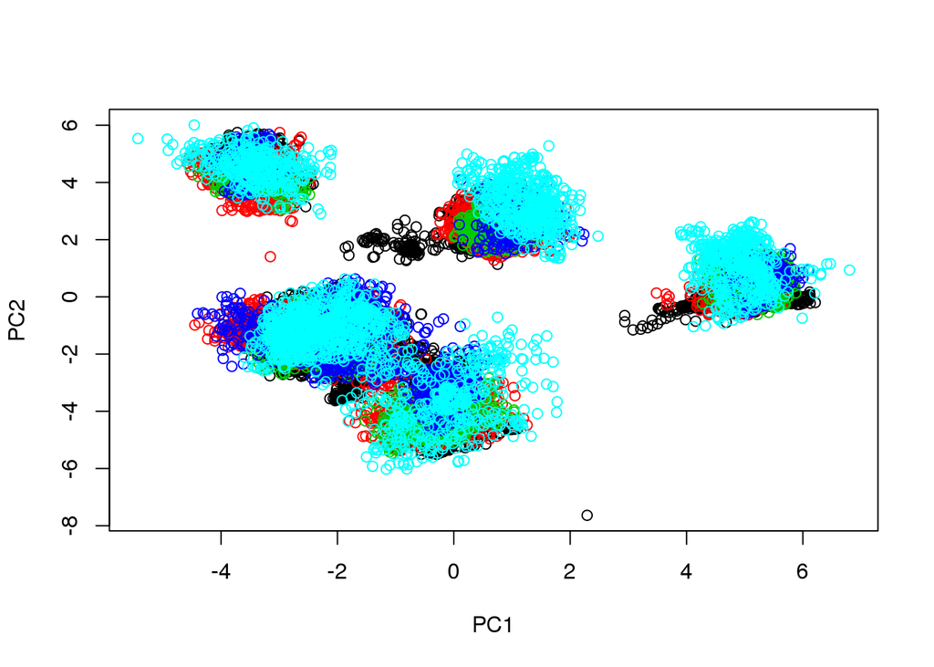

```r
#PCA Plot of the First Two components by "Classe" Variable
typeColor <- training$classe
# plot the first two principal components
plot(training.PC$PC1,training.PC$PC2,col=typeColor,xlab="PC1",ylab="PC2")
```

Diagram 1

#### PCA Plot of the First Two components by “User_name” Variable

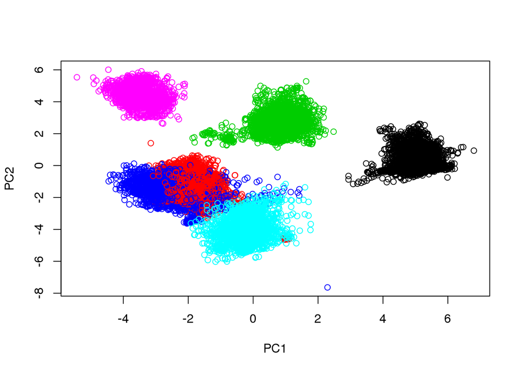

```r
#PCA Plot of the First Two components by "User_name" Variable
typeColor <- training$user_name
# plot the first two principal components
plot(training.PC$PC1,training.PC$PC2,col=typeColor,xlab="PC1",ylab="PC2")
```

Diagram 2